# Module 8

#### Hemi-module gene counts:

100 probesets in hemi-module A.  
105 probesets in hemi-module B.  
Note: While the mapping of probesets to genes is usually one-to-one, some genes are targeted by multiple probesets, some probesets target multiple genes, and some probesets do not target any genes (i.e., the region of the genome they match is no longer considered genic).

#### Contrast SVE:

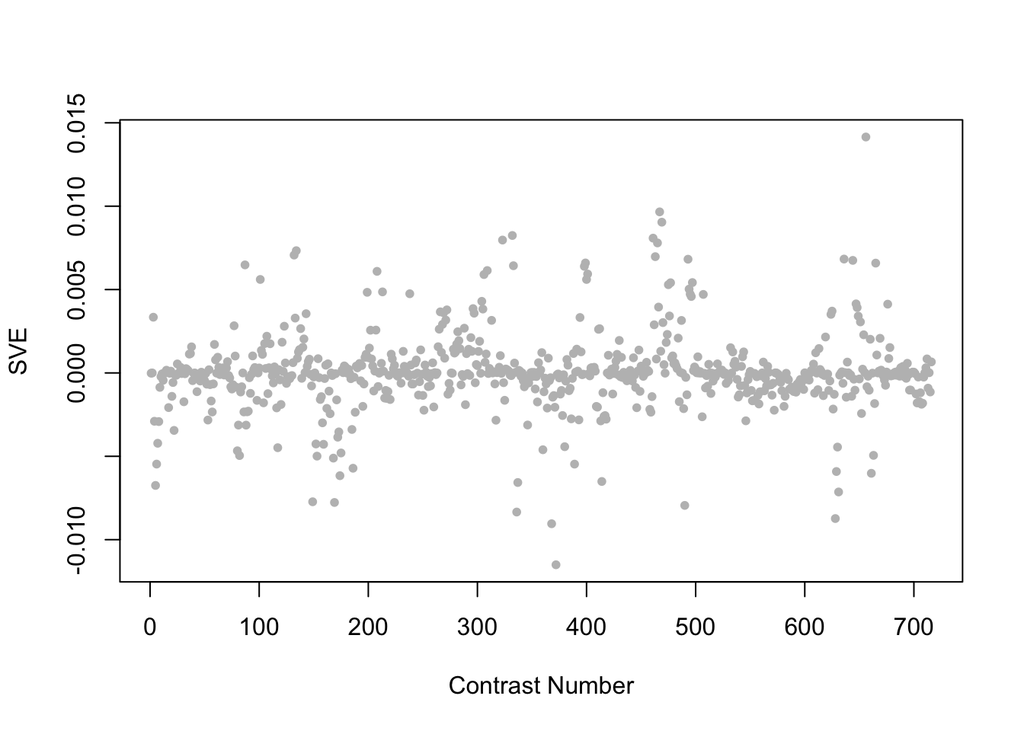

Positive SVE Contrasts:

|  | Contrast.Num | SVE | GEO.GSE | Cond.1 | Cond.2 | Mutation |
| --- | --- | --- | --- | --- | --- | --- |
| GSE16050.s1t1.vs.s0t1 | 656 | 0.01 | GSE16050 | MT_GFPp_rep1 | WT_GFPp_rep1 |  |
| GSE23528A.s1t1.vs.s0t1 | 467 | 0.01 | GSE23528 | Adult at T2 in LD, time-series experiment 3 | Adult at T2, non-entrained control time-series experiment 4 |  |
| GSE23528A.s1t6.vs.s0t6 | 469 | 0.01 | GSE23528 | Adult at T22 in LD, time-series experiment 3 | Adult at T22, non-entrained control time-series experiment 4 |  |
| GSE38997.s2t2.vs.s1t2 | 332 | 0.01 | GSE38997 | experiment 4 EtBr-exposed samples at 24 h 4e24 | experiment 4 control samples at 24 h 4c24 |  |
| GSE23528A.s1t3.vs.s0t3 | 461 | 0.01 | GSE23528 | Adult at T10 in LD, time-series experiment 3 | Adult at T10, non-entrained control time-series experiment 4 |  |

Negative SVE Contrasts:

|  | Contrast.Num | SVE | GEO.GSE | Cond.1 | Cond.2 | Mutation |
| --- | --- | --- | --- | --- | --- | --- |
| GSE35360C.s2t1.vs.s0t1 | 372 | -0.01 | GSE35360 | HFHQ 3d_2.0_rep1 | HFHQ 3d control_rep1 |  |
| GSE35360A.s2t1.vs.s0t1 | 368 | -0.01 | GSE35360 | HF 11d_2.0_rep1 | HF 11d control_rep1 |  |
| GSE19310A.s1t1.vs.s0t1 | 628 | -0.01 | GSE19310 | osm-11(n1604) at iso, rep1 | N2 at iso, rep1 | osm-11 |
| GSE38997.s4t2.vs.s2t2 | 336 | -0.01 | GSE38997 | experiment 4 UVC-exposed samples at 24 h 4u24 | experiment 4 EtBr-exposed samples at 24 h 4e24 |  |
| GSE23528B.s1t4.vs.s1t1 | 490 | -0.01 | GSE23528 | Adult at T38 in CC, time-series experiment 3 | Adult at T26 in CC, time-series experiment 3 |  |

$~$

#### Contrast SVE, Up-Regulated Genes Only:

Calculating SVE for up-regulated and down-regulated genes separately may be more informative in many cases than projecting the up- and down- gene sets together. This is due to the fact that the weight distribution of many modules is highly skewed, indicating that only one of the hemi-modules may be biologically meaningful (i.e., a set of genes are strongly correlated by only a few genes (or none) are strongly anti-correlated to that set.)

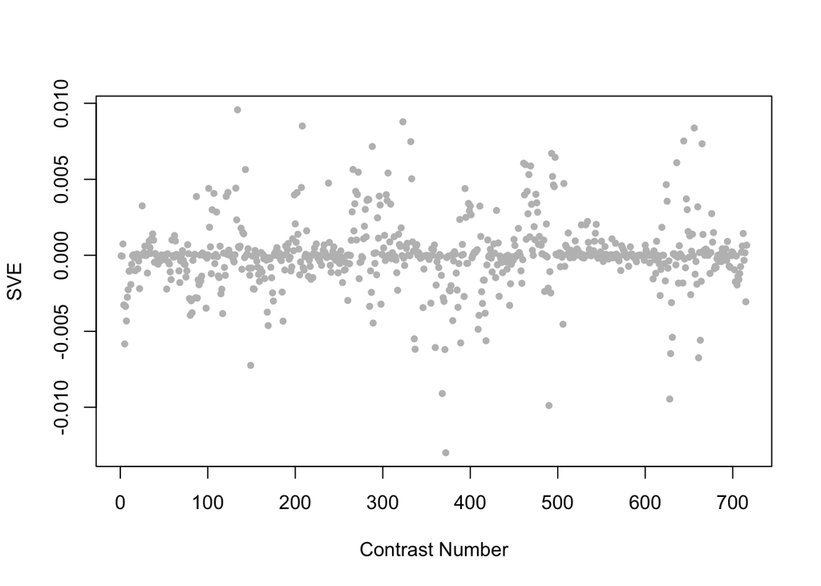

Positive SVE Contrasts:

|  | Contrast.Num | SVE | GEO.GSE | Cond.1 | Cond.2 | Mutation |
| --- | --- | --- | --- | --- | --- | --- |
| GSE52064.s1t1.vs.s4t1 | 134 | 0.01 | GSE52064 | wildtype_1 | lin-54;mes-4_1 | lin-54;mes-4 |
| GSE38997.s3t3.vs.s2t3 | 323 | 0.01 | GSE38997 | experiment 1 UVC- and EtBr-exposed samples at 48 h 1eu48 | experiment 1 EtBr-exposed samples at 48 h 1e48 |  |
| GSE42703.s2t2.vs.s2t1 | 208 | 0.01 | GSE42703 | WT incubated with H2O, biological rep1 | WT incubated with 1mM copper sulfate, biological rep1 |  |
| GSE16050.s1t1.vs.s0t1 | 656 | 0.01 | GSE16050 | MT_GFPp_rep1 | WT_GFPp_rep1 |  |
| GSE16915.s1t1.vs.s3t1 | 644 | 0.01 | GSE16915 | control sample | bio-electrosprayed sample |  |

Negative SVE Contrasts:

|  | Contrast.Num | SVE | GEO.GSE | Cond.1 | Cond.2 | Mutation |
| --- | --- | --- | --- | --- | --- | --- |
| GSE35360C.s2t1.vs.s0t1 | 372 | -0.01 | GSE35360 | HFHQ 3d_2.0_rep1 | HFHQ 3d control_rep1 |  |
| GSE23528B.s1t4.vs.s1t1 | 490 | -0.01 | GSE23528 | Adult at T38 in CC, time-series experiment 3 | Adult at T26 in CC, time-series experiment 3 |  |
| GSE19310A.s1t1.vs.s0t1 | 628 | -0.01 | GSE19310 | osm-11(n1604) at iso, rep1 | N2 at iso, rep1 | osm-11 |
| GSE35360A.s2t1.vs.s0t1 | 368 | -0.01 | GSE35360 | HF 11d_2.0_rep1 | HF 11d control_rep1 |  |
| GSE48347.s1t1.vs.s0t1 | 149 | -0.01 | GSE48347 | smo1_embryo_rep1 | WT_embryo_rep1 | smo-1 |

$~$

#### Contrast SVE, Down-Regulated Genes Only:

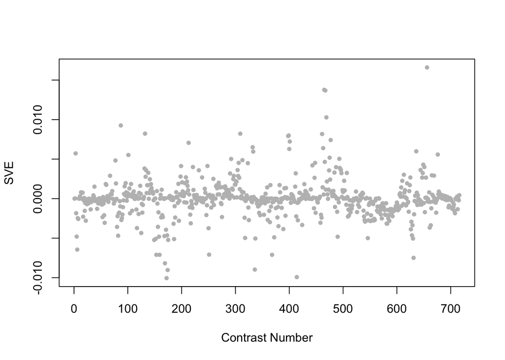

Positive SVE Contrasts:

|  | Contrast.Num | SVE | GEO.GSE | Cond.1 | Cond.2 | Mutation |
| --- | --- | --- | --- | --- | --- | --- |
| GSE16050.s1t1.vs.s0t1 | 656 | 0.02 | GSE16050 | MT_GFPp_rep1 | WT_GFPp_rep1 |  |
| GSE23528A.s1t5.vs.s0t5 | 465 | 0.01 | GSE23528 | Adult at T18 in LD, time-series experiment 3 | Adult at T18, non-entrained control time-series experiment 4 |  |
| GSE23528A.s1t1.vs.s0t1 | 467 | 0.01 | GSE23528 | Adult at T2 in LD, time-series experiment 3 | Adult at T2, non-entrained control time-series experiment 4 |  |
| GSE23528A.s1t6.vs.s0t6 | 469 | 0.01 | GSE23528 | Adult at T22 in LD, time-series experiment 3 | Adult at T22, non-entrained control time-series experiment 4 |  |
| GSE6547.s1t3.vs.s0t3 | 87 | 0.01 | GSE6547 | lin-35(n745) worms at L4 stage, first replicate | N2 (wt) worms at L4 stage, first replicate | lin-35 |

Negative SVE Contrasts:

|  | Contrast.Num | SVE | GEO.GSE | Cond.1 | Cond.2 | Mutation |
| --- | --- | --- | --- | --- | --- | --- |
| GSE47778.s5t3.vs.s2t3 | 172 | -0.01 | GSE47778 | xpa-1 10mJ/cm2; replicate 1 | daf-2; UV; replicate 1 | xpa-1 vs. daf-2 |
| GSE29951.s1t1.vs.s0t1 | 414 | -0.01 | GSE29951 | C.elegans MT KO mtl-1,mtl-2(zs1), raised in the absence of Cd, rep1 | C.elegans wild type raised in the absence of Cd, rep1 | mtl-1;mtl-2 |
| GSE47778.s5t3.vs.s4t3 | 174 | -0.01 | GSE47778 | xpa-1 10mJ/cm2; replicate 1 | daf-2;daf-16; UV; replicate 1 | xpa-1 vs. daf-2;daf-16 |
| GSE38997.s4t2.vs.s2t2 | 336 | -0.01 | GSE38997 | experiment 4 UVC-exposed samples at 24 h 4u24 | experiment 4 EtBr-exposed samples at 24 h 4e24 |  |
| GSE47778.s5t3.vs.s3t3 | 169 | -0.01 | GSE47778 | xpa-1 10mJ/cm2; replicate 1 | daf-16; UV; replicate 1 | xpa-1 vs. daf-16 |

$~$

$~$

#### GO Term Enrichment:

This analysis tests each hemi-module for enrichment of specific GO terms. Only gene-level annotations (e.g., as would be found on the gene’s page in Wormbase) are tested - the hierarchical structure of the GO ontology is not taken into account.

*Note: At least the top two most enriched terms from each GO domain (BP/MF/CC) are shown, even when not statistically significant.*

##### Enriched GO terms: Hemi-module A

| ID | GO.Term | GO Domain | Raw p-value | Adj p-value |
| --- | --- | --- | --- | --- |
| [GO_0006189](http://amigo.geneontology.org/amigo/term/GO:0006189) | ‘de novo’ IMP biosynthetic process | BP | 3.27e-04 | 9.98e-01 |
| [GO_0006164](http://amigo.geneontology.org/amigo/term/GO:0006164) | purine nucleotide biosynthetic process | BP | 1.18e-03 | 9.98e-01 |
| [GO_0003937](http://amigo.geneontology.org/amigo/term/GO:0003937) | IMP cyclohydrolase activity | MF | 4.74e-03 | 1.00e+00 |
| [GO_0004044](http://amigo.geneontology.org/amigo/term/GO:0004044) | amidophosphoribosyltransferase activity | MF | 4.74e-03 | 1.00e+00 |
| [GO_0005746](http://amigo.geneontology.org/amigo/term/GO:0005746) | mitochondrial respiratory chain | CC | 9.45e-03 | 1.00e+00 |
| [GO_0030173](http://amigo.geneontology.org/amigo/term/GO:0030173) | integral component of Golgi membrane | CC | 1.19e-02 | 1.00e+00 |

##### Enriched GO terms: Hemi-module B

| ID | GO.Term | GO Domain | Raw p-value | Adj p-value |
| --- | --- | --- | --- | --- |
| [GO_0019835](http://amigo.geneontology.org/amigo/term/GO:0019835) | cytolysis | BP | 1.77e-04 | 6.43e-01 |
| [GO_0035725](http://amigo.geneontology.org/amigo/term/GO:0035725) | sodium ion transmembrane transport | BP | 1.90e-03 | 9.98e-01 |
| [GO_0003796](http://amigo.geneontology.org/amigo/term/GO:0003796) | lysozyme activity | MF | 1.84e-05 | 3.76e-02 |
| [GO_0005272](http://amigo.geneontology.org/amigo/term/GO:0005272) | sodium channel activity | MF | 6.35e-04 | 6.49e-01 |
| [GO_0031906](http://amigo.geneontology.org/amigo/term/GO:0031906) | late endosome lumen | CC | 5.49e-03 | 9.99e-01 |
| [GO_0034777](http://amigo.geneontology.org/amigo/term/GO:0034777) | recycling endosome lumen | CC | 5.49e-03 | 9.99e-01 |

$~$

$~$

#### Tissue Enrichment:

This analysis tests each hemi-module for enrichment of genes associated with anatomy terms. Negative enrichment scores indicate fewer hemi-module genes than expected by random chance were associated with the anatomy term in question.

##### Enriched tissues: Hemi-module A

No significant annotations.

##### Enriched tissues: Hemi-module B

No significant annotations.

$~$

$~$

#### HOMER promoter motif enrichment:

This analysis tests each hemi-module for enrichment of 108 known *C. elegans* transcription factor binding site motifs (see [108 CE motifs](https://katiepod.github.io//all.worm.motifs.html)) using the HOMER (Hypergeometric Optimization of Motif EnRichment) software (see [PMID:20513432](https://pubmed.ncbi.nlm.nih.gov/20513432)). HOMER was run using default parameters on sequences 1 kb upstream of the transcription start site.

##### Motif enrichment: Hemi-module A

Total target sequences = 87  
Total background sequences = 40805  
* - possible false positive

Rank

Motif

P-value

log P-pvalue

% of Targets

% of Background

STD(Bg STD)

Best Match/Details

Motif File

1 *

[figure not shown]

1e-10

-2.501e+01

6.90%

0.05%

258.5bp (287.4bp)

MF0002.1_bZIP_CREB/G-box-like_subclass/Jaspar(0.561)  
[More Information](https://katiepod.github.io/HomerResults/m8_a_hemi_genes.txt.out.1kb/homerResults/motif1.info.html) | [Similar Motifs Found](https://katiepod.github.io/HomerResults/m8_a_hemi_genes.txt.out.1kb/homerResults/motif1.similar.html)

[motif file (matrix)](https://katiepod.github.io/HomerResults/m8_a_hemi_genes.txt.out.1kb/homerResults/motif1.motif)

2 *

[figure not shown]

1e-10

-2.466e+01

4.60%

0.00%

243.8bp (0.0bp)

zip-8/MA1704.1/Jaspar(0.609)  
[More Information](https://katiepod.github.io/HomerResults/m8_a_hemi_genes.txt.out.1kb/homerResults/motif2.info.html) | [Similar Motifs Found](https://katiepod.github.io/HomerResults/m8_a_hemi_genes.txt.out.1kb/homerResults/motif2.similar.html)

[motif file (matrix)](https://katiepod.github.io/HomerResults/m8_a_hemi_genes.txt.out.1kb/homerResults/motif2.motif)

3 *

[figure not shown]

1e-8

-2.055e+01

12.64%

0.97%

280.9bp (283.8bp)

POL012.1_TATA-Box/Jaspar(0.656)  
[More Information](https://katiepod.github.io/HomerResults/m8_a_hemi_genes.txt.out.1kb/homerResults/motif3.info.html) | [Similar Motifs Found](https://katiepod.github.io/HomerResults/m8_a_hemi_genes.txt.out.1kb/homerResults/motif3.similar.html)

[motif file (matrix)](https://katiepod.github.io/HomerResults/m8_a_hemi_genes.txt.out.1kb/homerResults/motif3.motif)

4 *

[figure not shown]

1e-8

-2.042e+01

4.60%

0.01%

53.1bp (144.5bp)

eor-1/MA0543.1/Jaspar(0.520)  
[More Information](https://katiepod.github.io/HomerResults/m8_a_hemi_genes.txt.out.1kb/homerResults/motif4.info.html) | [Similar Motifs Found](https://katiepod.github.io/HomerResults/m8_a_hemi_genes.txt.out.1kb/homerResults/motif4.similar.html)

[motif file (matrix)](https://katiepod.github.io/HomerResults/m8_a_hemi_genes.txt.out.1kb/homerResults/motif4.motif)

5 *

[figure not shown]

1e-8

-1.995e+01

12.64%

1.03%

304.3bp (278.5bp)

fkh-9/MA1440.1/Jaspar(0.668)  
[More Information](https://katiepod.github.io/HomerResults/m8_a_hemi_genes.txt.out.1kb/homerResults/motif5.info.html) | [Similar Motifs Found](https://katiepod.github.io/HomerResults/m8_a_hemi_genes.txt.out.1kb/homerResults/motif5.similar.html)

[motif file (matrix)](https://katiepod.github.io/HomerResults/m8_a_hemi_genes.txt.out.1kb/homerResults/motif5.motif)

6 *

[figure not shown]

1e-8

-1.925e+01

9.20%

0.41%

149.2bp (319.7bp)

unc-30/MA1443.1/Jaspar(0.585)  
[More Information](https://katiepod.github.io/HomerResults/m8_a_hemi_genes.txt.out.1kb/homerResults/motif6.info.html) | [Similar Motifs Found](https://katiepod.github.io/HomerResults/m8_a_hemi_genes.txt.out.1kb/homerResults/motif6.similar.html)

[motif file (matrix)](https://katiepod.github.io/HomerResults/m8_a_hemi_genes.txt.out.1kb/homerResults/motif6.motif)

7 *

[figure not shown]

1e-8

-1.875e+01

6.90%

0.15%

272.0bp (253.5bp)

POL004.1_CCAAT-box/Jaspar(0.656)  
[More Information](https://katiepod.github.io/HomerResults/m8_a_hemi_genes.txt.out.1kb/homerResults/motif7.info.html) | [Similar Motifs Found](https://katiepod.github.io/HomerResults/m8_a_hemi_genes.txt.out.1kb/homerResults/motif7.similar.html)

[motif file (matrix)](https://katiepod.github.io/HomerResults/m8_a_hemi_genes.txt.out.1kb/homerResults/motif7.motif)

8 *

[figure not shown]

1e-7

-1.826e+01

14.94%

1.89%

289.0bp (306.0bp)

unc-62/MA0918.1/Jaspar(0.631)  
[More Information](https://katiepod.github.io/HomerResults/m8_a_hemi_genes.txt.out.1kb/homerResults/motif8.info.html) | [Similar Motifs Found](https://katiepod.github.io/HomerResults/m8_a_hemi_genes.txt.out.1kb/homerResults/motif8.similar.html)

[motif file (matrix)](https://katiepod.github.io/HomerResults/m8_a_hemi_genes.txt.out.1kb/homerResults/motif8.motif)

9 *

[figure not shown]

1e-7

-1.814e+01

13.79%

1.56%

321.6bp (285.5bp)

POL012.1_TATA-Box/Jaspar(0.608)  
[More Information](https://katiepod.github.io/HomerResults/m8_a_hemi_genes.txt.out.1kb/homerResults/motif9.info.html) | [Similar Motifs Found](https://katiepod.github.io/HomerResults/m8_a_hemi_genes.txt.out.1kb/homerResults/motif9.similar.html)

[motif file (matrix)](https://katiepod.github.io/HomerResults/m8_a_hemi_genes.txt.out.1kb/homerResults/motif9.motif)

10 *

[figure not shown]

1e-7

-1.813e+01

12.64%

1.24%

306.9bp (309.4bp)

cebp-1/MA1444.1/Jaspar(0.567)  
[More Information](https://katiepod.github.io/HomerResults/m8_a_hemi_genes.txt.out.1kb/homerResults/motif10.info.html) | [Similar Motifs Found](https://katiepod.github.io/HomerResults/m8_a_hemi_genes.txt.out.1kb/homerResults/motif10.similar.html)

[motif file (matrix)](https://katiepod.github.io/HomerResults/m8_a_hemi_genes.txt.out.1kb/homerResults/motif10.motif)

11 *

[figure not shown]

1e-7

-1.805e+01

12.64%

1.24%

195.0bp (287.3bp)

pal-1/MA0924.1/Jaspar(0.552)  
[More Information](https://katiepod.github.io/HomerResults/m8_a_hemi_genes.txt.out.1kb/homerResults/motif11.info.html) | [Similar Motifs Found](https://katiepod.github.io/HomerResults/m8_a_hemi_genes.txt.out.1kb/homerResults/motif11.similar.html)

[motif file (matrix)](https://katiepod.github.io/HomerResults/m8_a_hemi_genes.txt.out.1kb/homerResults/motif11.motif)

12 *

[figure not shown]

1e-7

-1.779e+01

10.34%

0.72%

271.8bp (308.6bp)

mab-3/MA0262.1/Jaspar(0.599)  
[More Information](https://katiepod.github.io/HomerResults/m8_a_hemi_genes.txt.out.1kb/homerResults/motif12.info.html) | [Similar Motifs Found](https://katiepod.github.io/HomerResults/m8_a_hemi_genes.txt.out.1kb/homerResults/motif12.similar.html)

[motif file (matrix)](https://katiepod.github.io/HomerResults/m8_a_hemi_genes.txt.out.1kb/homerResults/motif12.motif)

13 *

[figure not shown]

1e-7

-1.725e+01

9.20%

0.54%

286.0bp (308.0bp)

cebp-1/MA1444.1/Jaspar(0.553)  
[More Information](https://katiepod.github.io/HomerResults/m8_a_hemi_genes.txt.out.1kb/homerResults/motif13.info.html) | [Similar Motifs Found](https://katiepod.github.io/HomerResults/m8_a_hemi_genes.txt.out.1kb/homerResults/motif13.similar.html)

[motif file (matrix)](https://katiepod.github.io/HomerResults/m8_a_hemi_genes.txt.out.1kb/homerResults/motif13.motif)

14 *

[figure not shown]

1e-7

-1.715e+01

12.64%

1.36%

358.4bp (298.1bp)

fkh-2/MA0920.1/Jaspar(0.616)  
[More Information](https://katiepod.github.io/HomerResults/m8_a_hemi_genes.txt.out.1kb/homerResults/motif14.info.html) | [Similar Motifs Found](https://katiepod.github.io/HomerResults/m8_a_hemi_genes.txt.out.1kb/homerResults/motif14.similar.html)

[motif file (matrix)](https://katiepod.github.io/HomerResults/m8_a_hemi_genes.txt.out.1kb/homerResults/motif14.motif)

15 *

[figure not shown]

1e-7

-1.618e+01

12.64%

1.50%

297.1bp (281.7bp)

SD0001.1_at_AC_acceptor/Jaspar(0.753)  
[More Information](https://katiepod.github.io/HomerResults/m8_a_hemi_genes.txt.out.1kb/homerResults/motif15.info.html) | [Similar Motifs Found](https://katiepod.github.io/HomerResults/m8_a_hemi_genes.txt.out.1kb/homerResults/motif15.similar.html)

[motif file (matrix)](https://katiepod.github.io/HomerResults/m8_a_hemi_genes.txt.out.1kb/homerResults/motif15.motif)

16 *

[figure not shown]

1e-6

-1.579e+01

4.60%

0.04%

250.6bp (251.1bp)

unc-86/MA0926.1/Jaspar(0.517)  
[More Information](https://katiepod.github.io/HomerResults/m8_a_hemi_genes.txt.out.1kb/homerResults/motif16.info.html) | [Similar Motifs Found](https://katiepod.github.io/HomerResults/m8_a_hemi_genes.txt.out.1kb/homerResults/motif16.similar.html)

[motif file (matrix)](https://katiepod.github.io/HomerResults/m8_a_hemi_genes.txt.out.1kb/homerResults/motif16.motif)

17 *

[figure not shown]

1e-6

-1.535e+01

5.75%

0.14%

404.7bp (312.6bp)

hlh-30/MA1449.1/Jaspar(0.575)  
[More Information](https://katiepod.github.io/HomerResults/m8_a_hemi_genes.txt.out.1kb/homerResults/motif17.info.html) | [Similar Motifs Found](https://katiepod.github.io/HomerResults/m8_a_hemi_genes.txt.out.1kb/homerResults/motif17.similar.html)

[motif file (matrix)](https://katiepod.github.io/HomerResults/m8_a_hemi_genes.txt.out.1kb/homerResults/motif17.motif)

18 *

[figure not shown]

1e-6

-1.489e+01

10.34%

1.03%

232.3bp (310.0bp)

elt-2/MA1701.1/Jaspar(0.662)  
[More Information](https://katiepod.github.io/HomerResults/m8_a_hemi_genes.txt.out.1kb/homerResults/motif18.info.html) | [Similar Motifs Found](https://katiepod.github.io/HomerResults/m8_a_hemi_genes.txt.out.1kb/homerResults/motif18.similar.html)

[motif file (matrix)](https://katiepod.github.io/HomerResults/m8_a_hemi_genes.txt.out.1kb/homerResults/motif18.motif)

19 *

[figure not shown]

1e-6

-1.476e+01

28.74%

9.57%

295.2bp (315.1bp)

PL0007.1_mxl-3/Jaspar(0.815)  
[More Information](https://katiepod.github.io/HomerResults/m8_a_hemi_genes.txt.out.1kb/homerResults/motif19.info.html) | [Similar Motifs Found](https://katiepod.github.io/HomerResults/m8_a_hemi_genes.txt.out.1kb/homerResults/motif19.similar.html)

[motif file (matrix)](https://katiepod.github.io/HomerResults/m8_a_hemi_genes.txt.out.1kb/homerResults/motif19.motif)

20 *

[figure not shown]

1e-6

-1.469e+01

14.94%

2.59%

251.0bp (302.8bp)

nhr-6/MA1451.1/Jaspar(0.824)  
[More Information](https://katiepod.github.io/HomerResults/m8_a_hemi_genes.txt.out.1kb/homerResults/motif20.info.html) | [Similar Motifs Found](https://katiepod.github.io/HomerResults/m8_a_hemi_genes.txt.out.1kb/homerResults/motif20.similar.html)

[motif file (matrix)](https://katiepod.github.io/HomerResults/m8_a_hemi_genes.txt.out.1kb/homerResults/motif20.motif)

21 *

[figure not shown]

1e-6

-1.456e+01

13.79%

2.18%

281.1bp (310.5bp)

ceh-10::ttx-3/MA0263.1/Jaspar(0.631)  
[More Information](https://katiepod.github.io/HomerResults/m8_a_hemi_genes.txt.out.1kb/homerResults/motif21.info.html) | [Similar Motifs Found](https://katiepod.github.io/HomerResults/m8_a_hemi_genes.txt.out.1kb/homerResults/motif21.similar.html)

[motif file (matrix)](https://katiepod.github.io/HomerResults/m8_a_hemi_genes.txt.out.1kb/homerResults/motif21.motif)

22 *

[figure not shown]

1e-6

-1.430e+01

9.20%

0.80%

245.4bp (288.5bp)

fkh-9/MA1440.1/Jaspar(0.710)  
[More Information](https://katiepod.github.io/HomerResults/m8_a_hemi_genes.txt.out.1kb/homerResults/motif22.info.html) | [Similar Motifs Found](https://katiepod.github.io/HomerResults/m8_a_hemi_genes.txt.out.1kb/homerResults/motif22.similar.html)

[motif file (matrix)](https://katiepod.github.io/HomerResults/m8_a_hemi_genes.txt.out.1kb/homerResults/motif22.motif)

23 *

[figure not shown]

1e-5

-1.369e+01

6.90%

0.37%

207.1bp (297.3bp)

lin-14/MA0261.1/Jaspar(0.633)  
[More Information](https://katiepod.github.io/HomerResults/m8_a_hemi_genes.txt.out.1kb/homerResults/motif23.info.html) | [Similar Motifs Found](https://katiepod.github.io/HomerResults/m8_a_hemi_genes.txt.out.1kb/homerResults/motif23.similar.html)

[motif file (matrix)](https://katiepod.github.io/HomerResults/m8_a_hemi_genes.txt.out.1kb/homerResults/motif23.motif)

24 *

[figure not shown]

1e-5

-1.322e+01

19.54%

5.11%

287.6bp (295.8bp)

MF0001.1_ETS_class/Jaspar(0.613)  
[More Information](https://katiepod.github.io/HomerResults/m8_a_hemi_genes.txt.out.1kb/homerResults/motif24.info.html) | [Similar Motifs Found](https://katiepod.github.io/HomerResults/m8_a_hemi_genes.txt.out.1kb/homerResults/motif24.similar.html)

[motif file (matrix)](https://katiepod.github.io/HomerResults/m8_a_hemi_genes.txt.out.1kb/homerResults/motif24.motif)

25 *

[figure not shown]

1e-5

-1.243e+01

24.14%

8.01%

300.8bp (296.2bp)

unc-86/MA0926.1/Jaspar(0.508)  
[More Information](https://katiepod.github.io/HomerResults/m8_a_hemi_genes.txt.out.1kb/homerResults/motif25.info.html) | [Similar Motifs Found](https://katiepod.github.io/HomerResults/m8_a_hemi_genes.txt.out.1kb/homerResults/motif25.similar.html)

[motif file (matrix)](https://katiepod.github.io/HomerResults/m8_a_hemi_genes.txt.out.1kb/homerResults/motif25.motif)

26 *

[figure not shown]

1e-5

-1.218e+01

8.05%

0.76%

346.9bp (288.3bp)

LIN-39(Homeobox)/cElegans.L3-LIN39-ChIP-Seq(modEncode)/Homer(0.613)  
[More Information](https://katiepod.github.io/HomerResults/m8_a_hemi_genes.txt.out.1kb/homerResults/motif26.info.html) | [Similar Motifs Found](https://katiepod.github.io/HomerResults/m8_a_hemi_genes.txt.out.1kb/homerResults/motif26.similar.html)

[motif file (matrix)](https://katiepod.github.io/HomerResults/m8_a_hemi_genes.txt.out.1kb/homerResults/motif26.motif)

27 *

[figure not shown]

1e-5

-1.185e+01

25.29%

9.02%

294.8bp (298.3bp)

PHA-4(Forkhead)/cElegans-Embryos-PHA4-ChIP-Seq(modEncode)/Homer(0.583)  
[More Information](https://katiepod.github.io/HomerResults/m8_a_hemi_genes.txt.out.1kb/homerResults/motif27.info.html) | [Similar Motifs Found](https://katiepod.github.io/HomerResults/m8_a_hemi_genes.txt.out.1kb/homerResults/motif27.similar.html)

[motif file (matrix)](https://katiepod.github.io/HomerResults/m8_a_hemi_genes.txt.out.1kb/homerResults/motif27.motif)

28 *

[figure not shown]

1e-4

-1.118e+01

8.05%

0.88%

263.4bp (282.9bp)

MF0006.1_bZIP_cEBP-like_subclass/Jaspar(0.473)  
[More Information](https://katiepod.github.io/HomerResults/m8_a_hemi_genes.txt.out.1kb/homerResults/motif28.info.html) | [Similar Motifs Found](https://katiepod.github.io/HomerResults/m8_a_hemi_genes.txt.out.1kb/homerResults/motif28.similar.html)

[motif file (matrix)](https://katiepod.github.io/HomerResults/m8_a_hemi_genes.txt.out.1kb/homerResults/motif28.motif)

29 *

[figure not shown]

1e-4

-1.097e+01

14.94%

3.65%

272.4bp (308.2bp)

MF0009.1_TRP(MYB)_class/Jaspar(0.727)  
[More Information](https://katiepod.github.io/HomerResults/m8_a_hemi_genes.txt.out.1kb/homerResults/motif29.info.html) | [Similar Motifs Found](https://katiepod.github.io/HomerResults/m8_a_hemi_genes.txt.out.1kb/homerResults/motif29.similar.html)

[motif file (matrix)](https://katiepod.github.io/HomerResults/m8_a_hemi_genes.txt.out.1kb/homerResults/motif29.motif)

30 *

[figure not shown]

1e-3

-8.221e+00

14.94%

4.81%

303.1bp (306.4bp)

lin-14/MA0261.1/Jaspar(0.566)  
[More Information](https://katiepod.github.io/HomerResults/m8_a_hemi_genes.txt.out.1kb/homerResults/motif30.info.html) | [Similar Motifs Found](https://katiepod.github.io/HomerResults/m8_a_hemi_genes.txt.out.1kb/homerResults/motif30.similar.html)

[motif file (matrix)](https://katiepod.github.io/HomerResults/m8_a_hemi_genes.txt.out.1kb/homerResults/motif30.motif)

##### Motif enrichment: Hemi-module B

Total target sequences = 77  
Total background sequences = 39490  
* - possible false positive

Rank

Motif

P-value

log P-pvalue

% of Targets

% of Background

STD(Bg STD)

Best Match/Details

Motif File

1 *

[figure not shown]

1e-9

-2.266e+01

27.27%

5.02%

285.1bp (331.4bp)

skn-1/MA0547.1/Jaspar(0.666)  
[More Information](https://katiepod.github.io/HomerResults/m8_b_hemi_genes.txt.out.1kb/homerResults/motif1.info.html) | [Similar Motifs Found](https://katiepod.github.io/HomerResults/m8_b_hemi_genes.txt.out.1kb/homerResults/motif1.similar.html)

[motif file (matrix)](https://katiepod.github.io/HomerResults/m8_b_hemi_genes.txt.out.1kb/homerResults/motif1.motif)

2 *

[figure not shown]

1e-9

-2.228e+01

31.17%

6.90%

269.5bp (335.4bp)

POL008.1_DCE_S_I/Jaspar(0.603)  
[More Information](https://katiepod.github.io/HomerResults/m8_b_hemi_genes.txt.out.1kb/homerResults/motif2.info.html) | [Similar Motifs Found](https://katiepod.github.io/HomerResults/m8_b_hemi_genes.txt.out.1kb/homerResults/motif2.similar.html)

[motif file (matrix)](https://katiepod.github.io/HomerResults/m8_b_hemi_genes.txt.out.1kb/homerResults/motif2.motif)

3 *

[figure not shown]

1e-8

-2.043e+01

7.79%

0.13%

344.1bp (365.9bp)

pha-4/MA0546.1/Jaspar(0.577)  
[More Information](https://katiepod.github.io/HomerResults/m8_b_hemi_genes.txt.out.1kb/homerResults/motif3.info.html) | [Similar Motifs Found](https://katiepod.github.io/HomerResults/m8_b_hemi_genes.txt.out.1kb/homerResults/motif3.similar.html)

[motif file (matrix)](https://katiepod.github.io/HomerResults/m8_b_hemi_genes.txt.out.1kb/homerResults/motif3.motif)

4 *

[figure not shown]

1e-8

-2.031e+01

49.35%

18.84%

286.7bp (329.2bp)

nhr-6/MA1451.1/Jaspar(0.623)  
[More Information](https://katiepod.github.io/HomerResults/m8_b_hemi_genes.txt.out.1kb/homerResults/motif4.info.html) | [Similar Motifs Found](https://katiepod.github.io/HomerResults/m8_b_hemi_genes.txt.out.1kb/homerResults/motif4.similar.html)

[motif file (matrix)](https://katiepod.github.io/HomerResults/m8_b_hemi_genes.txt.out.1kb/homerResults/motif4.motif)

5 *

[figure not shown]

1e-8

-2.028e+01

9.09%

0.25%

269.5bp (276.5bp)

SD0002.1_at_AC_acceptor/Jaspar(0.654)  
[More Information](https://katiepod.github.io/HomerResults/m8_b_hemi_genes.txt.out.1kb/homerResults/motif5.info.html) | [Similar Motifs Found](https://katiepod.github.io/HomerResults/m8_b_hemi_genes.txt.out.1kb/homerResults/motif5.similar.html)

[motif file (matrix)](https://katiepod.github.io/HomerResults/m8_b_hemi_genes.txt.out.1kb/homerResults/motif5.motif)

6 *

[figure not shown]

1e-8

-1.901e+01

10.39%

0.48%

233.1bp (331.3bp)

snpc-4/MA0544.1/Jaspar(0.540)  
[More Information](https://katiepod.github.io/HomerResults/m8_b_hemi_genes.txt.out.1kb/homerResults/motif6.info.html) | [Similar Motifs Found](https://katiepod.github.io/HomerResults/m8_b_hemi_genes.txt.out.1kb/homerResults/motif6.similar.html)

[motif file (matrix)](https://katiepod.github.io/HomerResults/m8_b_hemi_genes.txt.out.1kb/homerResults/motif6.motif)

7 *

[figure not shown]

1e-8

-1.889e+01

37.66%

11.90%

261.2bp (325.8bp)

POL012.1_TATA-Box/Jaspar(0.638)  
[More Information](https://katiepod.github.io/HomerResults/m8_b_hemi_genes.txt.out.1kb/homerResults/motif7.info.html) | [Similar Motifs Found](https://katiepod.github.io/HomerResults/m8_b_hemi_genes.txt.out.1kb/homerResults/motif7.similar.html)

[motif file (matrix)](https://katiepod.github.io/HomerResults/m8_b_hemi_genes.txt.out.1kb/homerResults/motif7.motif)

8 *

[figure not shown]

1e-8

-1.884e+01

9.09%

0.31%

346.1bp (321.5bp)

lin-54/MA1450.1/Jaspar(0.699)  
[More Information](https://katiepod.github.io/HomerResults/m8_b_hemi_genes.txt.out.1kb/homerResults/motif8.info.html) | [Similar Motifs Found](https://katiepod.github.io/HomerResults/m8_b_hemi_genes.txt.out.1kb/homerResults/motif8.similar.html)

[motif file (matrix)](https://katiepod.github.io/HomerResults/m8_b_hemi_genes.txt.out.1kb/homerResults/motif8.motif)

9 *

[figure not shown]

1e-8

-1.858e+01

14.29%

1.35%

175.6bp (315.8bp)

PQM-1(?)/cElegans-L3-ChIP-Seq(modEncode)/Homer(0.863)  
[More Information](https://katiepod.github.io/HomerResults/m8_b_hemi_genes.txt.out.1kb/homerResults/motif9.info.html) | [Similar Motifs Found](https://katiepod.github.io/HomerResults/m8_b_hemi_genes.txt.out.1kb/homerResults/motif9.similar.html)

[motif file (matrix)](https://katiepod.github.io/HomerResults/m8_b_hemi_genes.txt.out.1kb/homerResults/motif9.motif)

10 *

[figure not shown]

1e-6

-1.581e+01

5.19%

0.05%

113.6bp (211.1bp)

PL0014.1_mxl-1::mdl-1/Jaspar(0.506)  
[More Information](https://katiepod.github.io/HomerResults/m8_b_hemi_genes.txt.out.1kb/homerResults/motif10.info.html) | [Similar Motifs Found](https://katiepod.github.io/HomerResults/m8_b_hemi_genes.txt.out.1kb/homerResults/motif10.similar.html)

[motif file (matrix)](https://katiepod.github.io/HomerResults/m8_b_hemi_genes.txt.out.1kb/homerResults/motif10.motif)

11 *

[figure not shown]

1e-6

-1.575e+01

6.49%

0.14%

280.9bp (358.9bp)

PL0017.1_hlh-2::hlh-10/Jaspar(0.502)  
[More Information](https://katiepod.github.io/HomerResults/m8_b_hemi_genes.txt.out.1kb/homerResults/motif11.info.html) | [Similar Motifs Found](https://katiepod.github.io/HomerResults/m8_b_hemi_genes.txt.out.1kb/homerResults/motif11.similar.html)

[motif file (matrix)](https://katiepod.github.io/HomerResults/m8_b_hemi_genes.txt.out.1kb/homerResults/motif11.motif)

12 *

[figure not shown]

1e-6

-1.550e+01

25.97%

6.88%

307.5bp (325.2bp)

POL008.1_DCE_S_I/Jaspar(0.548)  
[More Information](https://katiepod.github.io/HomerResults/m8_b_hemi_genes.txt.out.1kb/homerResults/motif12.info.html) | [Similar Motifs Found](https://katiepod.github.io/HomerResults/m8_b_hemi_genes.txt.out.1kb/homerResults/motif12.similar.html)

[motif file (matrix)](https://katiepod.github.io/HomerResults/m8_b_hemi_genes.txt.out.1kb/homerResults/motif12.motif)

13 *

[figure not shown]

1e-6

-1.479e+01

15.58%

2.43%

269.9bp (313.1bp)

MF0011.1_HMG_class/Jaspar(0.556)  
[More Information](https://katiepod.github.io/HomerResults/m8_b_hemi_genes.txt.out.1kb/homerResults/motif13.info.html) | [Similar Motifs Found](https://katiepod.github.io/HomerResults/m8_b_hemi_genes.txt.out.1kb/homerResults/motif13.similar.html)

[motif file (matrix)](https://katiepod.github.io/HomerResults/m8_b_hemi_genes.txt.out.1kb/homerResults/motif13.motif)

14 *

[figure not shown]

1e-6

-1.434e+01

11.69%

1.25%

256.9bp (309.3bp)

skn-1/MA0547.1/Jaspar(0.599)  
[More Information](https://katiepod.github.io/HomerResults/m8_b_hemi_genes.txt.out.1kb/homerResults/motif14.info.html) | [Similar Motifs Found](https://katiepod.github.io/HomerResults/m8_b_hemi_genes.txt.out.1kb/homerResults/motif14.similar.html)

[motif file (matrix)](https://katiepod.github.io/HomerResults/m8_b_hemi_genes.txt.out.1kb/homerResults/motif14.motif)

15 *

[figure not shown]

1e-6

-1.432e+01

11.69%

1.25%

267.9bp (318.9bp)

lin-14/MA0261.1/Jaspar(0.641)  
[More Information](https://katiepod.github.io/HomerResults/m8_b_hemi_genes.txt.out.1kb/homerResults/motif15.info.html) | [Similar Motifs Found](https://katiepod.github.io/HomerResults/m8_b_hemi_genes.txt.out.1kb/homerResults/motif15.similar.html)

[motif file (matrix)](https://katiepod.github.io/HomerResults/m8_b_hemi_genes.txt.out.1kb/homerResults/motif15.motif)

16 *

[figure not shown]

1e-5

-1.297e+01

6.49%

0.26%

321.9bp (312.8bp)

cebp-1/MA1444.1/Jaspar(0.627)  
[More Information](https://katiepod.github.io/HomerResults/m8_b_hemi_genes.txt.out.1kb/homerResults/motif16.info.html) | [Similar Motifs Found](https://katiepod.github.io/HomerResults/m8_b_hemi_genes.txt.out.1kb/homerResults/motif16.similar.html)

[motif file (matrix)](https://katiepod.github.io/HomerResults/m8_b_hemi_genes.txt.out.1kb/homerResults/motif16.motif)

17 *

[figure not shown]

1e-5

-1.246e+01

3.90%

0.03%

140.0bp (381.5bp)

pha-4/MA0546.1/Jaspar(0.528)  
[More Information](https://katiepod.github.io/HomerResults/m8_b_hemi_genes.txt.out.1kb/homerResults/motif17.info.html) | [Similar Motifs Found](https://katiepod.github.io/HomerResults/m8_b_hemi_genes.txt.out.1kb/homerResults/motif17.similar.html)

[motif file (matrix)](https://katiepod.github.io/HomerResults/m8_b_hemi_genes.txt.out.1kb/homerResults/motif17.motif)

18 *

[figure not shown]

1e-5

-1.155e+01

9.09%

0.95%

234.4bp (337.4bp)

blmp-1/MA0537.1/Jaspar(0.605)  
[More Information](https://katiepod.github.io/HomerResults/m8_b_hemi_genes.txt.out.1kb/homerResults/motif18.info.html) | [Similar Motifs Found](https://katiepod.github.io/HomerResults/m8_b_hemi_genes.txt.out.1kb/homerResults/motif18.similar.html)

[motif file (matrix)](https://katiepod.github.io/HomerResults/m8_b_hemi_genes.txt.out.1kb/homerResults/motif18.motif)

19 *

[figure not shown]

1e-4

-1.096e+01

40.26%

19.25%

285.6bp (330.6bp)

POL008.1_DCE_S_I/Jaspar(0.574)  
[More Information](https://katiepod.github.io/HomerResults/m8_b_hemi_genes.txt.out.1kb/homerResults/motif19.info.html) | [Similar Motifs Found](https://katiepod.github.io/HomerResults/m8_b_hemi_genes.txt.out.1kb/homerResults/motif19.similar.html)

[motif file (matrix)](https://katiepod.github.io/HomerResults/m8_b_hemi_genes.txt.out.1kb/homerResults/motif19.motif)

20 *

[figure not shown]

1e-4

-1.020e+01

2.60%

0.01%

280.8bp (318.9bp)

MF0004.1_Nuclear_Receptor_class/Jaspar(0.573)  
[More Information](https://katiepod.github.io/HomerResults/m8_b_hemi_genes.txt.out.1kb/homerResults/motif20.info.html) | [Similar Motifs Found](https://katiepod.github.io/HomerResults/m8_b_hemi_genes.txt.out.1kb/homerResults/motif20.similar.html)

[motif file (matrix)](https://katiepod.github.io/HomerResults/m8_b_hemi_genes.txt.out.1kb/homerResults/motif20.motif)

21 *

[figure not shown]

1e-4

-9.709e+00

6.49%

0.52%

213.6bp (324.7bp)

fos-1/MA1448.1/Jaspar(0.584)  
[More Information](https://katiepod.github.io/HomerResults/m8_b_hemi_genes.txt.out.1kb/homerResults/motif21.info.html) | [Similar Motifs Found](https://katiepod.github.io/HomerResults/m8_b_hemi_genes.txt.out.1kb/homerResults/motif21.similar.html)

[motif file (matrix)](https://katiepod.github.io/HomerResults/m8_b_hemi_genes.txt.out.1kb/homerResults/motif21.motif)

22 *

[figure not shown]

1e-4

-9.254e+00

18.18%

5.63%

347.3bp (306.1bp)

POL003.1_GC-box/Jaspar(0.695)  
[More Information](https://katiepod.github.io/HomerResults/m8_b_hemi_genes.txt.out.1kb/homerResults/motif22.info.html) | [Similar Motifs Found](https://katiepod.github.io/HomerResults/m8_b_hemi_genes.txt.out.1kb/homerResults/motif22.similar.html)

[motif file (matrix)](https://katiepod.github.io/HomerResults/m8_b_hemi_genes.txt.out.1kb/homerResults/motif22.motif)

23 *

[figure not shown]

1e-3

-8.941e+00

15.58%

4.38%

300.0bp (300.0bp)

POL013.1_MED-1/Jaspar(0.636)  
[More Information](https://katiepod.github.io/HomerResults/m8_b_hemi_genes.txt.out.1kb/homerResults/motif23.info.html) | [Similar Motifs Found](https://katiepod.github.io/HomerResults/m8_b_hemi_genes.txt.out.1kb/homerResults/motif23.similar.html)

[motif file (matrix)](https://katiepod.github.io/HomerResults/m8_b_hemi_genes.txt.out.1kb/homerResults/motif23.motif)

$~$

$~$

#### Promoter Word Enrichment:

This analysis tests each hemi-module for enrichment of specific promoter words. The list of promoter words tested was generated by running the MobyDick algorithm (see [PMID:10944202](https://pubmed.ncbi.nlm.nih.gov/10944202)) on the full set of *C. elegans* 2 Kbp promoters.

##### Enriched promoter words: Hemi-module A

No significant words.

##### Enriched promoter words: Hemi-module B

No significant words.

$~$

$~$

#### Promoter Word Depletion:

This analysis tests each hemi-module for depletion (under-enrichment) of specific promoter words. The list of promoter words tested was generated by running the MobyDick algorithm (see [PMID:10944202](https://pubmed.ncbi.nlm.nih.gov/10944202)) on the full set of *C. elegans* 2 Kbp promoters.

##### Depleted promoter words: Hemi-module A

No significant words.

##### Depleted promoter words: Hemi-module B

No significant words.

$~$

$~$

#### 3’-UTR Word Enrichment:

This analysis tests each hemi-module for enrichment of specific 3’-UTR words. The list of words tested was generated by running the MobyDick algorithm (see [PMID:10944202](https://pubmed.ncbi.nlm.nih.gov/10944202)) on the full set of *C. elegans* 3’-UTR sequences.

##### 3’-UTR words: Hemi-module A

No significant words.

##### 3’-UTR words: Hemi-module B

No significant words.

$~$

$~$

#### Hemi-module A genes

| affy_c_elegans | ensembl_gene_id | external_gene_name | module_weight | chromosome_name | strand | start_position | end_position |
| --- | --- | --- | --- | --- | --- | --- | --- |
| 183552_s_at | WBGene00019176 | H10D12.2 | 6.02 | IV | -1 | 6143183 | 6149923 |
| 183552_s_at | WBGene00166267 | 21ur-7970 | 6.02 | IV | -1 | 6143869 | 6143889 |
| 188978_s_at | WBGene00010759 | cysl-2 | 5.10 | II | -1 | 14492826 | 14494514 |
| 188570_at | WBGene00011166 | chil-22 | 5.05 | II | -1 | 9464470 | 9466195 |
| 172533_x_at | WBGene00013646 | Y105C5B.3 | 4.46 | IV | 1 | 15884222 | 15888419 |
| 172533_x_at | WBGene00171351 | 21ur-12703 | 4.46 | IV | 1 | 15887391 | 15887411 |
| 176549_at | WBGene00021854 | Y54F10AR.1 | 4.40 | III | -1 | 2572031 | 2575723 |
| 189575_at | WBGene00011673 | cyp-13A6 | 4.36 | II | -1 | 9800761 | 9802721 |
| 185770_at | WBGene00004945 | sop-2 | 4.34 | II | 1 | 12339944 | 12344795 |
| 184047_at | WBGene00017315 | ugt-36 | 4.31 | V | 1 | 7167009 | 7169281 |
| 185594_at | WBGene00016484 | C36C5.15 | 4.27 | V | -1 | 3167968 | 3168750 |
| 182705_at | WBGene00018888 | F55F1.2 | 4.23 | X | -1 | 2769588 | 2770060 |
| 182538_at | WBGene00015800 | C15H9.4 | 4.23 | X | 1 | 6101158 | 6105526 |
| 181239_s_at | WBGene00015272 | C01B4.8 | 4.21 | V | 1 | 2490512 | 2492701 |
| 181239_s_at | WBGene00021220 | Y19D10A.5 | 4.21 | V | 1 | 2382233 | 2384422 |
| 194055_at | WBGene00012661 | clec-163 | 4.17 | III | 1 | 10794349 | 10796369 |
| 179681_at | WBGene00011135 | fbxa-147 | 4.16 | V | 1 | 14716499 | 14717425 |
| 182395_at | WBGene00001732 | grl-23 | 4.15 | V | -1 | 12575308 | 12576895 |
| 179365_at | WBGene00008227 | C50B8.5 | 4.13 | V | 1 | 13580993 | 13584643 |
| 184185_at | WBGene00008201 | C49C3.11 | 4.10 | IV | 1 | 17343782 | 17344805 |
| 188010_at | WBGene00012683 | asp-17 | 4.10 | V | -1 | 19035753 | 19037320 |
| 184715_at | WBGene00015697 | mlst-8 | 4.09 | I | -1 | 4735471 | 4738100 |
| 173203_at | WBGene00004622 | rrn-3.1 | 4.06 | I | 1 | 15064838 | 15068346 |
| 178571_s_at | WBGene00007989 | fipr-22 | 4.05 | I | 1 | 14155470 | 14156316 |
| 178571_s_at | WBGene00007990 | fipr-23 | 4.05 | I | -1 | 14153270 | 14154168 |
| 178028_at | WBGene00008970 | F20C5.5 | 4.04 | IV | -1 | 8767688 | 8770092 |
| 194189_x_at | WBGene00004622 | rrn-3.1 | 3.98 | I | 1 | 15064838 | 15068346 |
| 180204_at | WBGene00009433 | F35E12.9 | 3.95 | V | -1 | 13741321 | 13745127 |
| 173372_at | WBGene00004622 | rrn-3.1 | 3.95 | I | 1 | 15064838 | 15068346 |
| 173372_at | WBGene00004677 | rrn-3.56 | 3.95 | I | 1 | 15060299 | 15061150 |
| 189200_at | WBGene00006785 | unc-50 | 3.95 | III | -1 | 10314490 | 10318162 |
| 179836_at | WBGene00019496 | frpr-14 | 3.93 | II | 1 | 650964 | 654062 |
| 175468_at | WBGene00020208 | T04C4.1 | 3.93 | IV | 1 | 2222828 | 2235795 |
| 193599_at | WBGene00009214 | thn-3 | 3.91 | IV | 1 | 12381592 | 12382339 |
| 185141_at | WBGene00021118 | clec-125 | 3.89 | II | 1 | 3516008 | 3518898 |
| 173392_s_at | WBGene00004622 | rrn-3.1 | 3.88 | I | 1 | 15064838 | 15068346 |
| 185242_at | WBGene00013648 | Y105C5B.7 | 3.81 | IV | -1 | 15914997 | 15919234 |
| 185242_at | WBGene00046600 | 21ur-4062 | 3.81 | IV | -1 | 15916585 | 15916605 |
| 185242_at | WBGene00165614 | 21ur-12704 | 3.81 | IV | -1 | 15916249 | 15916269 |
| 185242_at | WBGene00169454 | 21ur-10965 | 3.81 | IV | -1 | 15916463 | 15916483 |
| 185242_at | WBGene00170312 | 21ur-9412 | 3.81 | IV | -1 | 15916586 | 15916606 |
| 185242_at | WBGene00174598 | 21ur-13824 | 3.81 | IV | -1 | 15916250 | 15916270 |
| 184710_at | WBGene00021183 | Y9C9A.16 | 3.79 | IV | -1 | 4973622 | 4976089 |
| 173113_at | WBGene00000552 | cmd-1 | 3.78 | V | 1 | 1156271 | 1158174 |
| 182195_at | WBGene00015601 | fbxa-166 | 3.75 | II | -1 | 1616912 | 1619004 |
| 172220_x_at | WBGene00007989 | fipr-22 | 3.75 | I | 1 | 14155470 | 14156316 |
| 172220_x_at | WBGene00007990 | fipr-23 | 3.75 | I | -1 | 14153270 | 14154168 |
| 171904_x_at | WBGene00004622 | rrn-3.1 | 3.74 | I | 1 | 15064838 | 15068346 |
| 189419_at | WBGene00008850 | F15B9.6 | 3.73 | V | 1 | 13014144 | 13016641 |
| 192008_s_at | WBGene00020583 | T19D12.9 | 3.72 | II | -1 | 6652339 | 6654384 |
| 192596_s_at | WBGene00011404 | T03F7.7 | 3.72 | V | 1 | 11311456 | 11313445 |
| 173149_at | WBGene00004622 | rrn-3.1 | 3.71 | I | 1 | 15064838 | 15068346 |
| 191910_at | WBGene00011407 | ppat-1 | 3.71 | III | 1 | 4689280 | 4692166 |
| 183908_at | WBGene00017302 | F09F7.5 | 3.70 | III | 1 | 5546987 | 5551231 |
| 173599_s_at | WBGene00013020 | Y48G10A.3 | 3.70 | I | -1 | 13471683 | 13474185 |
| 185290_at | WBGene00012959 | Y47H10A.3 | 3.64 | I | -1 | 12088120 | 12089969 |

#### Hemi-module B genes

| affy_c_elegans | ensembl_gene_id | external_gene_name | module_weight | chromosome_name | strand | start_position | end_position |
| --- | --- | --- | --- | --- | --- | --- | --- |
| 180721_at | WBGene00016669 | ilys-2 | -6.56 | IV | 1 | 2467681 | 2468810 |
| 180946_at | WBGene00016670 | ilys-3 | -5.25 | IV | 1 | 2464456 | 2465401 |
| 179281_at | WBGene00010009 | F53H4.4 | -4.88 | X | 1 | 15866411 | 15868764 |
| 179245_at | WBGene00010189 | F57B1.6 | -4.66 | V | 1 | 13209645 | 13213462 |
| 190834_at | WBGene00000133 | amt-1 | -4.61 | X | 1 | 4571448 | 4573914 |
| 172290_x_at | WBGene00016895 | C53B7.6 | -4.57 | X | -1 | 6868632 | 6868769 |
| 184646_at | WBGene00013510 | Y71A12B.13 | -4.37 | I | 1 | 13961011 | 13969571 |
| 193276_at | WBGene00002996 | lin-7 | -4.31 | II | -1 | 14346877 | 14348792 |
| 184635_at | WBGene00001185 | egl-17 | -4.29 | X | 1 | 489695 | 492273 |
| 184860_at | WBGene00016551 | C40A11.8 | -4.28 | II | -1 | 2150552 | 2151290 |
| 179227_at | WBGene00011202 | R10E4.6 | -4.27 | III | 1 | 4293408 | 4295142 |
| 179586_at | WBGene00008817 | F14F8.9 | -4.25 | V | -1 | 16667691 | 16668573 |
| 176183_at | WBGene00022096 | Y69A2AR.25 | -4.23 | IV | -1 | 2565820 | 2568367 |
| 187017_at | WBGene00022295 | cng-2 | -4.23 | IV | 1 | 2037191 | 2043191 |
| 176038_at | WBGene00021512 | Y41D4B.4 | -4.14 | IV | 1 | 1660112 | 1669707 |
| 182976_at | WBGene00016066 | acd-2 | -4.12 | I | 1 | 4094179 | 4098330 |
| 180390_at | WBGene00016280 | C31B8.2 | -4.09 | V | 1 | 2916523 | 2918034 |
| 187320_at | WBGene00015374 | C03B1.3 | -4.08 | X | 1 | 6366013 | 6366831 |
| 173357_s_at | WBGene00021800 | Y53G8AL.2 | -4.07 | III | -1 | 3241717 | 3248575 |
| 184023_at | WBGene00017022 | D1022.3 | -4.07 | II | -1 | 7455192 | 7456284 |
| 185370_at | WBGene00045297 | fbxc-43 | -4.06 | II | -1 | 4234950 | 4235982 |
| 176086_at | WBGene00021512 | Y41D4B.4 | -4.02 | IV | 1 | 1660112 | 1669707 |
| 193226_at | WBGene00011852 | clec-26 | -3.99 | V | 1 | 16848611 | 16850130 |
| 193328_at | WBGene00013972 | scl-20 | -3.92 | V | -1 | 18732802 | 18734466 |
| 176286_at | WBGene00022083 | Y69A2AR.12 | -3.90 | IV | 1 | 2568614 | 2572056 |
| 188942_s_at | WBGene00009001 | tyr-3 | -3.83 | I | -1 | 7274282 | 7278573 |
| 178825_at | WBGene00008209 | C49F5.5 | -3.81 | X | 1 | 11985880 | 11987229 |
| 182687_at | WBGene00044570 | T22B7.8 | -3.81 | X | 1 | 5631869 | 5638096 |
| 176299_at | WBGene00044348 | Y71G12B.31 | -3.77 | I | -1 | 1686216 | 1693457 |
| 173948_s_at | WBGene00009431 | dct-17 | -3.77 | V | -1 | 13727763 | 13730776 |
| 184993_at | WBGene00019146 | H02F09.3 | -3.76 | X | 1 | 1568678 | 1572854 |
| 176276_s_at | WBGene00022083 | Y69A2AR.12 | -3.75 | IV | 1 | 2568614 | 2572056 |
| 176276_s_at | WBGene00022096 | Y69A2AR.25 | -3.75 | IV | -1 | 2565820 | 2568367 |
| 191487_at | WBGene00007145 | B0334.5 | -3.73 | II | 1 | 11497665 | 11499620 |
| 187015_at | WBGene00014037 | ZK643.6 | -3.73 | III | -1 | 8957704 | 8960693 |
| 183690_at | WBGene00007454 | C08F11.7 | -3.73 | IV | 1 | 13637288 | 13638525 |
| 181229_at | WBGene00017743 | F23F1.2 | -3.70 | II | 1 | 34204 | 35262 |
| 172098_x_at | WBGene00021616 | Y47D7A.2 | -3.68 | V | 1 | 4420275 | 4420746 |
| 184531_s_at | WBGene00021134 | W10G11.1 | -3.68 | II | -1 | 3559651 | 3560692 |
| 191995_at | WBGene00001538 | gcy-12 | -3.67 | II | 1 | 5312046 | 5319234 |
| 180234_at | WBGene00022553 | ZC204.1 | -3.66 | II | 1 | 1666325 | 1667482 |